# Lab-7

eagbozo@urfu.ru

## Tidy Anomaly Detection

### Case — Bitcoin Price Anomaly Detection (Bitcoin Price since January 2018)

Anomalies – observations that do not conform with the pattern of the data.

- Point Anomaly – a global or contextual outlier.
- Collective Anomaly - observations that are credible in their context but unusual as a group.

Anomaly detection is a data science application that combines multiple data science tasks like classification, regression, and clustering.

Install the following packages using **devtools** *note that I have commented them outs*

```r
#devtools::install_github("business-science/anomalize")
#devtools::install_github("amrrs/coindeskr")


library(anomalize) #tidy anomaly detection
```

```r
library(tidyverse) #tidyverse packages like dplyr, ggplot, tidyr
library(coindeskr) #bitcoin price extraction from coindesk - https://github.com/amrrs/coindeskr
```

Extract historical bitcoin pricing data

```r
bitcoin <- get_historic_price(start = "2018-01-01")
```

take a look at how the data frame appears - we observe it has row names and one (1) column/variable

```r
head(bitcoin)
```

```
##               Price
## 2018-01-01 13412.44
## 2018-01-02 14740.76
## 2018-01-03 15134.65
## 2018-01-04 15155.23
## 2018-01-05 16937.17
## 2018-01-06 17135.84
```

#### Preprocessing phase

= rownames_to_column() removes row names and convert to a column - as_tibble() turns an existing object, such as a data frame, list, or matrix, into a so-called tibble - one_of() Matches variable names in a character vector. (the -one_of() function removes the column ‘rowname’)

```r
bitcoin_time_series <- bitcoin %>%
  rownames_to_column() %>% as_tibble() %>%
  mutate(date = as.Date(rowname)) %>% select(-one_of('rowname'))

head(bitcoin_time_series)
```

```
## # A tibble: 6 x 2
##    Price date
##    <dbl> <date>
## 1 13412. 2018-01-01
## 2 14741. 2018-01-02
## 3 15135. 2018-01-03
## 4 15155. 2018-01-04
## 5 16937. 2018-01-05
## 6 17136. 2018-01-06
```

##### TimeSeries Decomposition with time_decompose()

Once the components are decomposed, anomalize can detect and flag anomalies inthe decomposed data of the reminder component which then could be visualized with plot_anomaly_decomposition() .

The decomposition of time series is a statistical task that deconstructs a time series into several components, each representing one of the underlying categories of patterns Read More - https://machinelearningmastery.com/decompose-time-series-data-trend-seasonality/

Decomposition is primarily used for time series analysis, and as an analysis tool it can be used to inform forecasting models on your problem.

It provides a structured way of thinking about a time series forecasting problem, both generally in terms of modeling complexity and specifically in terms of how to best capture each of these components in a given model.

**for anomalize():** - The IQR method is faster at the expense of possibly not being quite as accurate.  
- The GESD method has the best properties for outlier detection, but is loop-based and therefore a bit slower source: (https://www.rdocumentation.org/packages/anomalize/versions/0.2.0/topics/anomalize).

```
## Converting from tbl_df to tbl_time.
## Auto-index message: index = date
```

```
## frequency = 7 days
```

```
## trend = 91 days
```

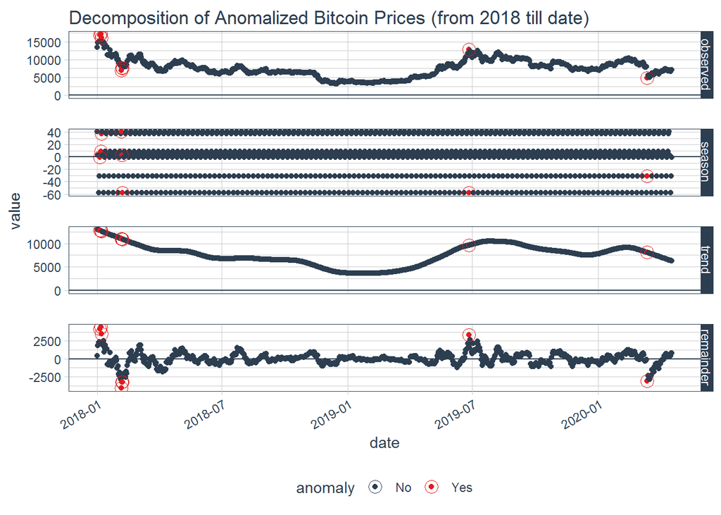

```r
bitcoin_time_series %>%
  anomalize::time_decompose(Price) %>%
  anomalize::anomalize(remainder) %>%
  anomalize::plot_anomaly_decomposition() +
  labs(title = "Decomposition of Anomalized Bitcoin Prices (from 2018 till date)")
```

Another approach to anomaly detection could be:

```
## Converting from tbl_df to tbl_time.
## Auto-index message: index = date
```

```
## frequency = 7 days
```

```
## trend = 91 days
```

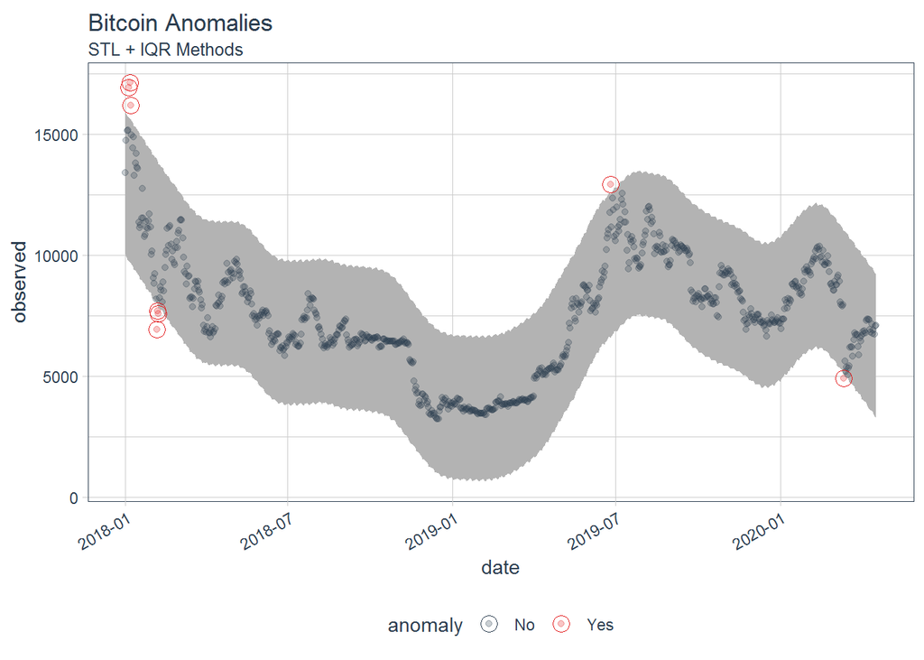

```r
bitcoin_time_series %>%
  # Data Manipulation / Anomaly Detection
  anomalize::time_decompose(Price, method = "stl", frequency="auto", trend="auto") %>%
  anomalize::anomalize(remainder, method = "iqr",alpha=0.05, max_anoms=0.5) %>%
  anomalize::time_recompose() %>%
  # Anomaly Visualization
  anomalize::plot_anomalies(time_recomposed = TRUE, ncol = 3, alpha_dots = 0.25) +
  labs(title = "Bitcoin Anomalies", subtitle = "STL + IQR Methods")
```